# Study hard, play hard

Daniel Kaplan

Based on an extensive but fictive observation of activity and grades of college students, the model shown in the figure was constructed to give GPA as a function of the number of hours each weekday (Monday-Friday) spent studying and spent in social activity and play. (Activity during the weekend was not monitored.)

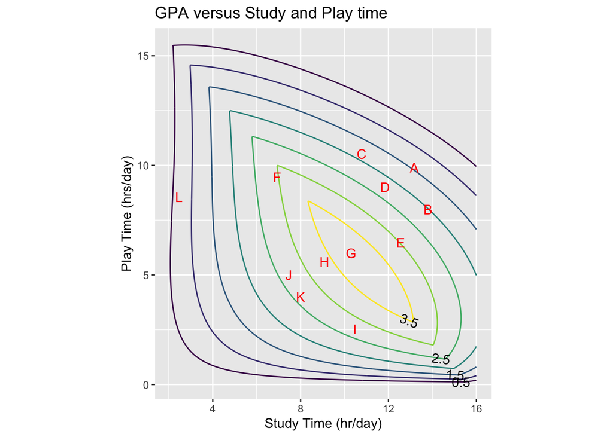

Several points in the graphic frame have been marked with red letters. Refer to these letters when answering the following questions.

**Question tmp-1**: According to the model, what’s the optimal combination of Study and Play to achieve a high GPA?

1. F []
2. G (+) []
3. H []
4. I []

**Question tmp-2**: Which of these letters marks a place on the graph where the partial derivative of GPA with respect to Play is positive?

1. B []
2. C []
3. K (+) []
4. L []

**Question tmp-3**: Which if these ketters marks a place on the graph where the partial derivative of GPA with respect to Play is negative.

1. A (+) []
2. F []
3. H []
4. K []

**Question tmp-4**: Where is the partial derivative with respect to Study is negative?

1. Nowhere. $\partial_{study} GPA()$ is always positive. More study = better grades. []
2. E (+) []
3. F []
4. L []

**Question tmp-5**: Study and Play are not the only activities possible. Sleep is important, too, as are meals, personal care, etc. In the study, students were observed who spent up to 22 hours per day in Study or Play. Presumably, such students crashed on the weekend.

Suppose you decide to budget 12 hours each weekday day in activities other than Study and Play. Which letter labels the constrained optimal mix (argmax) of Study and Play.

1. I []
2. J []
3. K (+) []
4. L []

**Question tmp-6**: What is the “shadow price” of GPA with respect to the budget for a budget constraint of 12 hours? Give both an estimated numerical value as well as units.

1. -0.8 hour/gradepoints []
2. 0.3 gradepoints/hour (+) []
3. +0.9 gradepoints/hour []
4. +1.3 hour/gradepoints []

**Question tmp-7**: Consider a student who budgets 22 hours per day for Study and Play. Which letter is closest to the constrained argmax with a 22-hour constraint?

1. A []
2. B (+) []
3. C []
4. D []

**Question tmp-8**: What is the “shadow price” of GPA with respect to the budget constraint of 22 hours? Give the estimated numerical value.

1. -0.5 gradepoints/hour (+) []
2. 0 gradepoints/hour []
3. +0.5 gradepoints/hour []
4. +1.0 gradepoints/hour []

**Question tmp-9**: Based on the shadow price from the previous question, which of these is the best advice to give the student (who seeks to maximize GPA)?

1. You’re hopeless. There aren’t enough hours in the day for you to get a good GPA. []
2. You’ve got to squeeze out more effort studying. Give it your all! []
3. Play more, study less! []
4. Study less []
5. Study less, play less. Sleep! (+) []